# Chicago Crime Dataset Analysis

Ayomide Abel Adeboyejo

2024-12-12

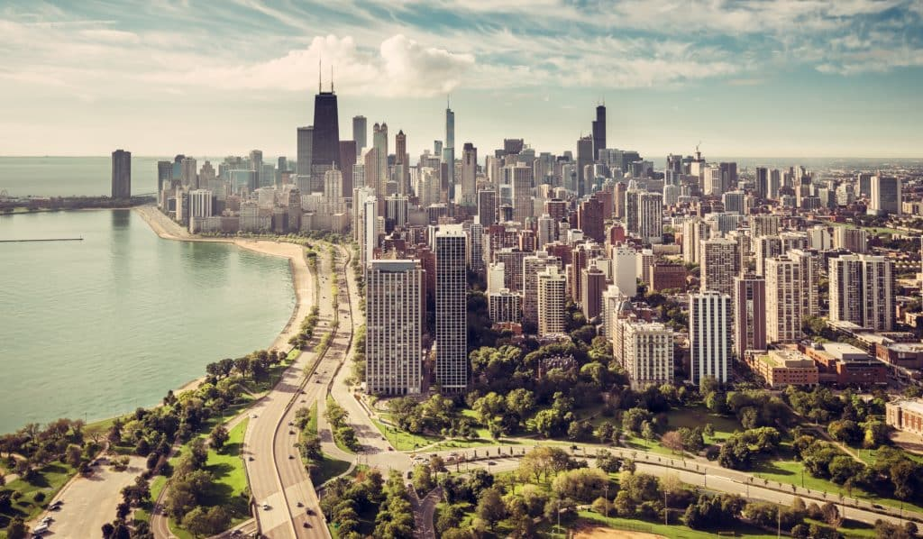

## Introduction

**Introduction**

This report analyzes crime trends in Chicago from 2020 to 2024 using publicly available data. The focus is on identifying trends in crime categories, geographic distribution, arrest patterns, and temporal variations. The findings aim to provide actionable insights for policymakers and law enforcement agencies.

**Probelem Statement**

Despite significant efforts by law enforcement agencies and policymakers, crime rates in Chicago continue to fluctuate across various categories and geographic areas, particularly between 2020 and 2024. This inconsistency makes it challenging to identify actionable patterns, assess the effectiveness of arrests, and predict future crime trends. Furthermore, the lack of advanced analytical techniques in decision-making processes leaves critical insights into crime dynamics, such as influencing factors and high-risk zones, unexplored. This hampers the development of targeted interventions and resource allocation strategies to reduce crime and improve public safety effectively.

## Data Life Cycle

The data lifecycle for this analysis involves several stages:

**Data Collection**: The dataset was sourced from the Chicago Police Department’s publicly available crime records. This data includes records of reported crimes from 2020 to 2024.

**Data Preparation**: The raw data was preprocessed to remove irrelevant or incomplete records. Key steps included filtering for the years 2020–2024, handling missing values, and creating derived columns such as `Year` and `Month`.

**Data Analysis**: The prepared data was analyzed to identify trends, patterns, and relationships. This step included calculating descriptive statistics, grouping data, and visualizing trends.

**Data Visualization**: Charts, maps, and visual summaries were created to represent crime trends, arrest patterns, and geographic distributions.

**Insights and Reporting**: The results were synthesized into actionable insights, with visualizations and narratives provided in this RMarkdown report.

**Key Columns for Analysis**

The following columns from the dataset were identified as critical for the analysis:

- Date
- Primary Type
- Arrest
- Domestic
- Community Area
- Latitude/Longitude
- Location.Description

## Visualizations

### **Exploratory Data Analysis**

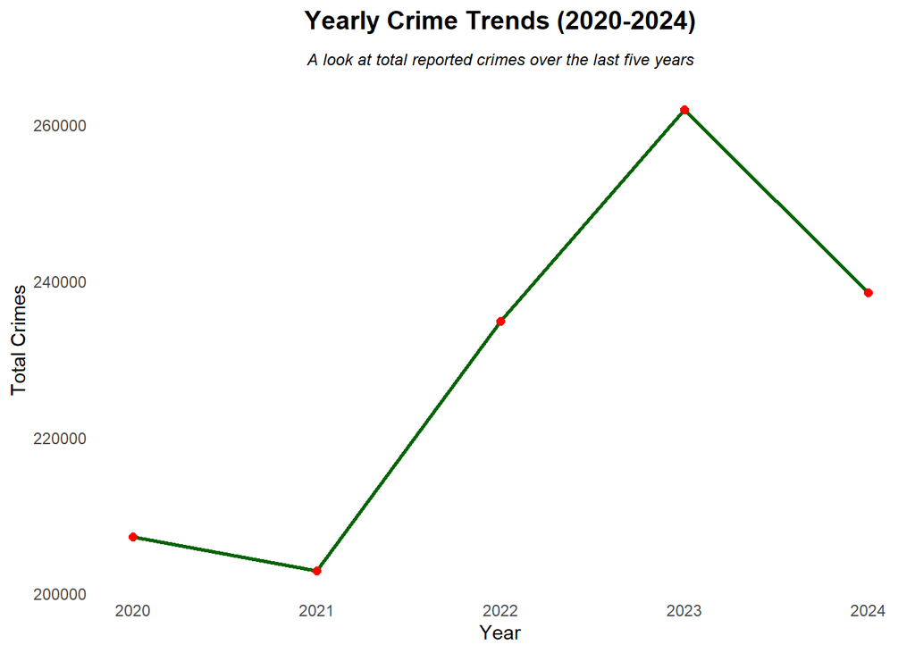

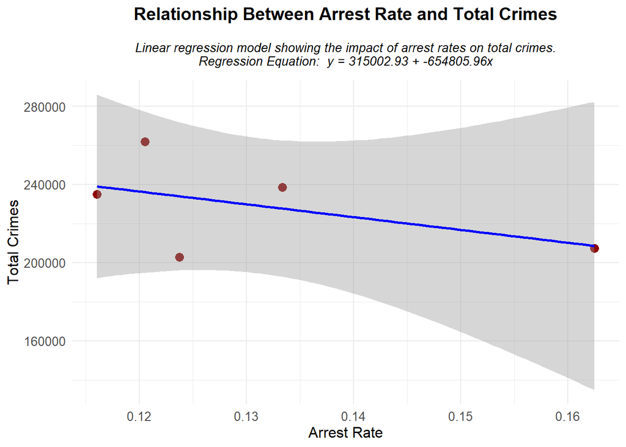

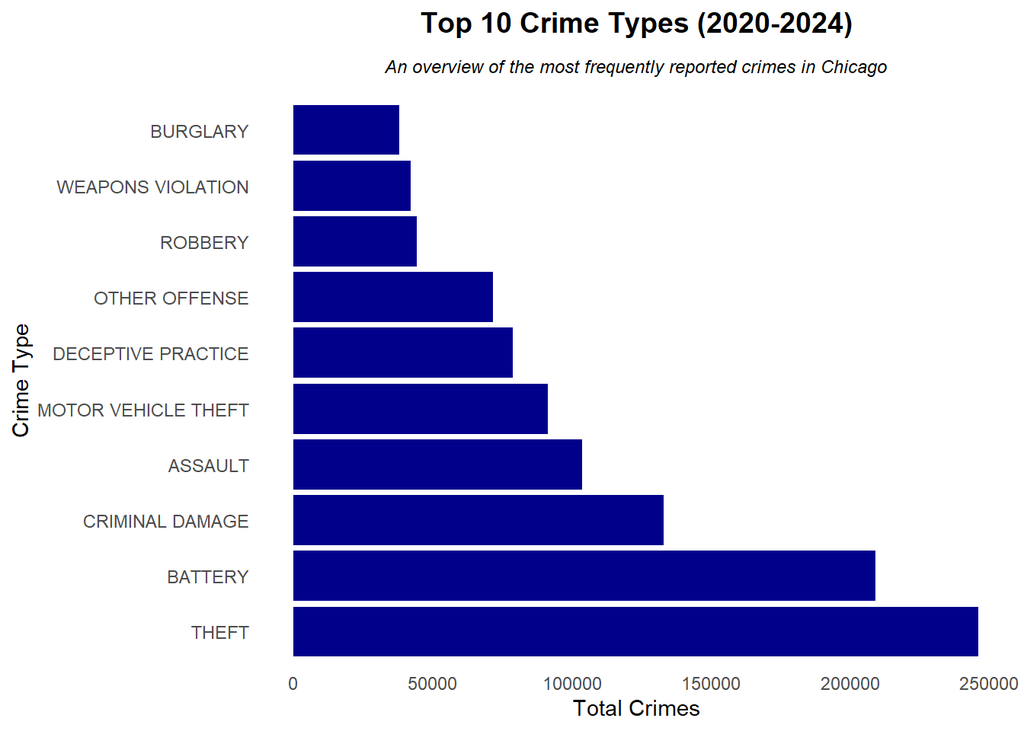

### **Geographic Analysis**

[interactive chart not shown]

### **Advanced Analysis**

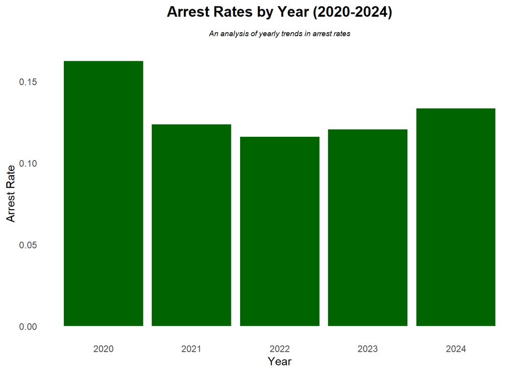

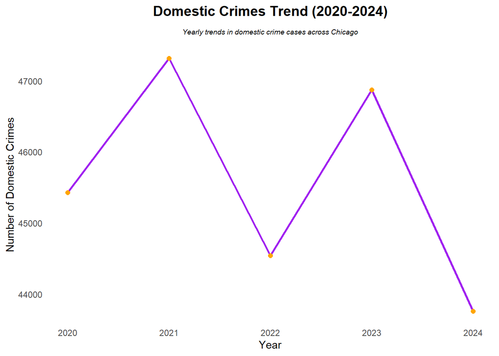

## Recommendations

**Recommendations**

- Focus law enforcement resources on identified crime hotspots and deploy predictive analytics for proactive interventions.
- Implement seasonal crime reduction strategies during months with historically high crime rates.
- Enhance investigative capabilities and use advanced technology to improve arrest rates, particularly for unsolved crimes.
- Collaborate with social services and launch community outreach programs to address domestic violence.
- Strengthen community policing initiatives to foster trust, encourage reporting, and engage neighborhoods in crime prevention efforts.

**References**

[Exploring Chicago Crime Trends: Comprehensive Dataset of Reported Crimes (2001 to Present)](https://data.cityofchicago.org/Public-Safety/Crimes-2001-to-Present/ijzp-q8t2/about_data)